- rfutbin
  - Installation
  - Functions
  - Examples
  - Citation

[figure not shown]

# rfutbin

R package to get price and stats of FIFA Ultimate Team players in [Futbin](https://www.futbin.com).

## Installation

This package is available only on GitHub. To install it, use the `devtools` package:

```r
library(devtools)
install_github("danielredondo/rfutbin")

library(rfutbin)
```

## Functions

### futbin_search

`futbin_search` searchs players in Futbin. It has the following parameters:

- `name`. Optional. Vector with the names of the players. If not specified, it will report the 30 highest-rated players of the game.
- `version`. Optional. Version of the cards. Some options are “Rare”, “Non-Rare”, “IF” (In-Form), “SIF” (Second In-Form), …
- `verbose`. Optional. To show additional messages (webpage scraped and number of players found).

The output of the function is a dataframe with all the players found searching for `name` and `version`.

### futbin_scrap

`futbin_scrap` extracts all players of a Futbin URL. It has the following parameters:

- `url`. Futbin URL to web scrap. Futbin webpage (https://www.futbin.com/players) can be used to make customised filters, and then copy the URL here. All the players found in the URL (and the next pages) will be automatically detected and downloaded.
- `sleep_time`. Time (in seconds) ellapsed between scraping one page and the next one. Please respect Futbin API.
- `verbose`. Optional. To show additional verbose about webpage used and number of players found.

The output of the function is a dataframe with all the players found at the URL.

### futbin_plot

`futbin_plot` makes an interactive radar plot of the stats of the players. It has the following parameters:

- `df` dataframe generated with columns `pac`, `sho`, `pas`, `dri`, `def`, `phy`. This dataframe can be obtained from function `futbin_search`.
- `gk` Optional. If `TRUE`, the labels of the plot are the main stats for goalkeepers: diving, handling, kicking, reflexes, speed and position.

The output of the function is an interactive radar plot of the stats.

## Examples

#### Load package

```r
library(rfutbin)
```

#### Search for a player

```r
futbin_search(name = "Lionel Messi")
```

```
#>           name rating position         version   price skills weak_foot pac sho
#> 1 Lionel Messi     98       RW            TOTY 2640000      4         4  93  98
#> 2 Lionel Messi     96       CF LaLiga POTM SBC 1710000      4         4  90  96
#> 3 Lionel Messi     95       CF           TOTGS  710000      4         4  88  95
#> 4 Lionel Messi     94       CF              IF  510000      4         4  86  94
#> 5 Lionel Messi     93       RW            Rare  115000      4         4  85  92
#> 6 Lionel Messi     93       RW              CL  115000      4         4  85  92
#>   pas dri def phy hei popularity base_stats in_game_stats wr_attack wr_defense
#> 1  97  99  43  73 170       5816        503          2449         M          L
#> 2  95  98  41  70 170       4410        490          2384         M          L
#> 3  94  97  40  68 170       2141        482          2348         M          L
#> 4  93  96  39  66 170       4962        474          2315         M          L
#> 5  91  95  38  65 170       7114        466          2273         M          L
#> 6  91  95  38  65 170        813        466          2273         M          L
#>   wei
#> 1  72
#> 2  72
#> 3  72
#> 4  72
#> 5  72
#> 6  72
```

#### Search for more than one player

```r
futbin_search(name = c("Lionel Messi", "Cristiano Ronaldo"))
```

```
#>                 name rating position         version   price skills weak_foot
#> 1       Lionel Messi     98       RW            TOTY 2640000      4         4
#> 2       Lionel Messi     96       CF LaLiga POTM SBC 1710000      4         4
#> 3       Lionel Messi     95       CF           TOTGS  710000      4         4
#> 4       Lionel Messi     94       CF              IF  510000      4         4
#> 5       Lionel Messi     93       RW            Rare  115000      4         4
#> 6       Lionel Messi     93       RW              CL  115000      4         4
#> 7  Cristiano Ronaldo     98       ST            TOTY 6470000      5         4
#> 8  Cristiano Ronaldo     95       ST             TIF 3390000      5         4
#> 9  Cristiano Ronaldo     94       ST             SIF 2450000      5         4
#> 10 Cristiano Ronaldo     93       ST              IF 1400000      5         4
#> 11 Cristiano Ronaldo     92       ST            Rare  335000      5         4
#> 12 Cristiano Ronaldo     92       ST              CL  333000      5         4
#> 13 Cristiano Ronaldo     87       RW   Flashback SBC  334500      5         3
#>    pac sho pas dri def phy hei popularity base_stats in_game_stats wr_attack
```

[output cut: 27 more lines]

#### Search for a specific version of a player

```r
# Lewandowski rare card
futbin_search(name = "Lewandowski", version = "Rare")
```

```
#>                 name rating position version price skills weak_foot pac sho pas
#> 6 Robert Lewandowski     91       ST    Rare 59000      4         4  78  91  78
#>   dri def phy hei popularity base_stats in_game_stats wr_attack wr_defense wei
#> 6  86  43  82 184       2058        458          2232         H          M  80
```

```r
# Luis Suarez One to watch (OTW)
futbin_search(name = "Luis Suarez", version = "OTW")
```

```
#>          name rating position version price skills weak_foot pac sho pas dri
#> 2 Luis Suárez     89       ST     OTW 50000      3         4  73  92  86  86
#>   def phy hei popularity base_stats in_game_stats wr_attack wr_defense wei
#> 2  53  85 182        842        475          2326         H          M  86
```

```r
# Grealish In-Form (IF) showing verbose
futbin_search(name = "Grealish", version = "IF", verbose = TRUE)
```

```
#> [1] "Reading... https://www.futbin.com/21/players?page=1&search=grealish"
#> [1] "Player(s) found: 1"
#>            name rating position version price skills weak_foot pac sho pas dri
#> 2 Jack Grealish     83       LM      IF 30500      4         3  80  77  84  87
#>   def phy hei popularity base_stats in_game_stats wr_attack wr_defense wei
#> 2  49  64 180        523        441          2066         M          M  68
```

#### Download all players from a Futbin webpage

```r
# All Aston Villa players -> To get the URL, go to futbin.com/players and filter
aston_villa <- futbin_scrap(url = "https://www.futbin.com/players?page=1&club=2")
```

```
#> [1] "Reading... https://www.futbin.com/players?page=1&club=2"
#> [1] "Player(s) found: 30"
#> [1] "Reading... https://www.futbin.com/players?page=2&club=2"
#> [1] "Player(s) found: 41"
#> [1] "Reading... https://www.futbin.com/players?page=3&club=2"
#> [1] "Player(s) found: 41"
```

```r
head(aston_villa)
```

```
#>                name rating position              version price skills weak_foot
#> 1     Jack Grealish     87      CAM TOTY Honourable Ment     0      4         3
#> 2     Ollie Watkins     84       ST                  SIF 31750      3         4
#> 3 Emiliano Martínez     84       GK                  SIF 44500      1         3
#> 4     Jack Grealish     83       LM                   IF 30500      4         3
#> 5 Emiliano Martínez     82       GK                   IF 35000      1         3
#> 6     Ollie Watkins     81       ST                   IF 19250      3         4
#>   pac sho pas dri def phy hei popularity base_stats in_game_stats wr_attack
#> 1  85  83  89  91  53  69 180       4630        470          2217         M
#> 2  90  84  77  82  54  76 180       3923        463          2188         H
#> 3  85  86  84  86  65  85 195        503        491          1078         M
#> 4  80  77  84  87  49  64 180        523        441          2066         M
#> 5  82  84  82  83  62  82 195        178        475          1072         M
#> 6  88  79  73  78  51  73 180        838        442          2068         H
#>   wr_defense wei
#> 1          M  68
#> 2          H  70
#> 3          M
#> 4          M  68
#> 5          M
#> 6          H  70
```

```r
# All English players in Bundesliga -> To get the URL, go to futbin.com/players and filter
futbin_scrap(url = "https://www.futbin.com/21/players?page=1&league=19&nation=14")
```

```
#> [1] "Reading... https://www.futbin.com/21/players?page=1&league=19&nation=14"
#> [1] "Player(s) found: 13"
#> [1] "Reading... https://www.futbin.com/21/players?page=2&league=19&nation=14"
#> [1] "Player(s) found: 13"
#>               name rating position         version  price skills weak_foot pac
#> 1     Jadon Sancho     92       RM         What If 328000      5         3  91
#> 2     Jadon Sancho     89       LM Bundes POTM SBC 134500      5         3  87
#> 3     Jadon Sancho     88       RM  Record Breaker  92000      5         3  87
#> 4     Jadon Sancho     87       RM            Rare  25000      5         3  83
#> 5     Jadon Sancho     87       RM              CL  25500      5         3  83
#> 6   Ryan Sessegnon     87       LM      Objectives      0      4         4  92
#> 7   Ryan Sessegnon     75       LM        non-rare    800      4         3  86
#> 8     Demarai Gray     75       LM        non-rare    850      4         3  87
#> 9  Ademola Lookman     74       RM            Rare  29500      3         4  82
#> 10 Jude Bellingham     69       CM        Non-Rare   1200      3         4  77
```

[output cut: 31 more lines]

#### Radar plot comparing Van Dijk and Messi

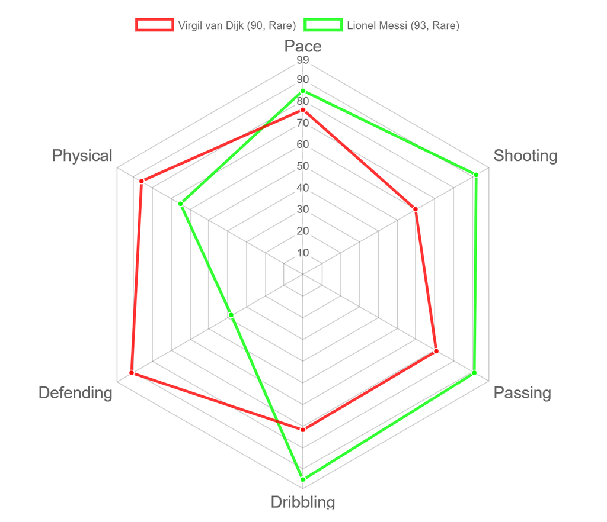

```r
players <- futbin_search(name = c("Van Dijk", "Lionel Messi"), version = "Rare")
futbin_plot(players)
```

*(Please note that this is a static version. Real plots are interactive.)*

#### Radar plot comparing goalkeepers:

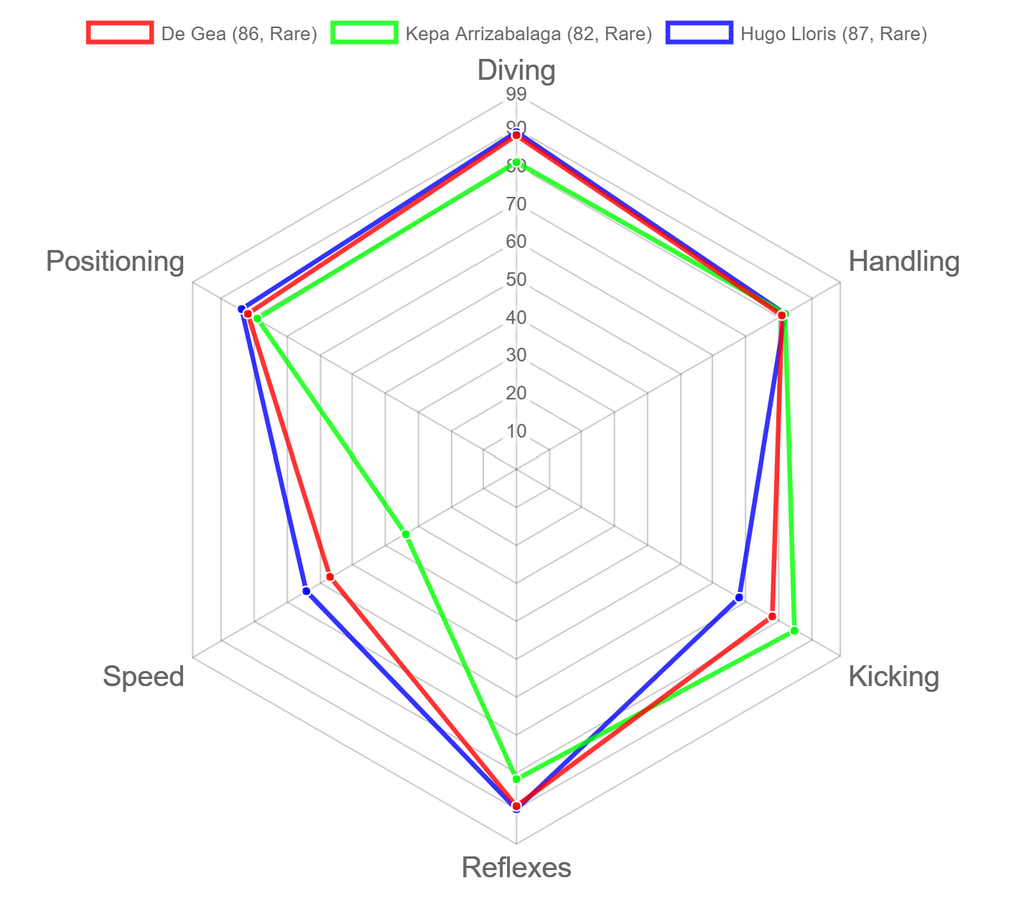

```r
some_goalkeepers <- futbin_search(name = c("De Gea", "Kepa", "Hugo Lloris"), version = "Rare")
futbin_plot(some_goalkeepers, gk = TRUE)
```

*(Please note that this is a static version. Real plots are interactive.)*

## Citation

If you use this package, you can cite it as:

```
Redondo-Sanchez, Daniel (2020). rfutbin: R package to get price and stats of FIFA Ultimate Team players in Futbin
```